# 22 - Bayesian statistics with brms

Francisco E. Fonturbel

26/September/2026

# A different way of thinking about uncertainty

During this course we have fitted many models using different approaches (ANOVAs, GLMs, GLMMs, GAMs, meta-analyses) and all of them had something in common: we obtained a *p*-value and decided whether an effect was “significant” or not. That is the **frequentist** approach, and it answers a rather strange question: *how likely are these data (or more extreme ones) if the null hypothesis were true?*

Most of the time, what we really want to know is the opposite: *given these data, how likely is it that the effect is positive? how big is it? how sure am I?* That is exactly what **Bayesian statistics** answers. Instead of a single point estimate and a *p*-value, we obtain a full probability distribution (the **posterior**) for every parameter in our model.

## Bayes’ theorem in a nutshell

Everything in Bayesian statistics comes from this simple rule:

$$P(\theta \mid \text{data}) \propto
P(\text{data} \mid \theta) \times P(\theta)$$

- $P(\theta)$ is the **prior**: what we know (or assume) about the parameter *before* looking at the data.
- $P(\text{data} \mid \theta)$ is the **likelihood**: the same thing we have been maximizing in all our GLMs.
- $P(\theta \mid \text{data})$ is the **posterior**: our updated knowledge after seeing the data.

So, the posterior is a compromise between the prior and the data. When we have a lot of data, the likelihood dominates and results are very similar to frequentist ones. When we have little data (very common in field ecology!), the prior helps to stabilize the estimates.

## A warm-up without any fancy software

Let’s go back to the mistletoe data of [Fontúrbel et al. (2015)](https://besjournals.onlinelibrary.wiley.com/doi/abs/10.1111/1365-2745.12443) that we used in lesson 11. We monitored 70 mistletoe plants with camera traps. A simple question: **what is the probability that a given plant gets visited by the marsupial *Dromiciops gliroides*?**

```r
data<-read.csv("data/11_mistletoe_data.csv",
                     header=TRUE,
                     sep=";",
                     dec=".",
                     na.strings="NA")
data$s250clasif<-as.factor(data$s250clasif)

n_plants<-nrow(data)
n_visited<-sum(data$dg_visits > 0)
n_plants
```

```
## [1] 70
```

```r
n_visited
```

```
## [1] 30
```

We can compute the posterior for the visitation probability ($\theta$) by brute force, evaluating Bayes’ theorem over a grid of possible values between 0 and 1 (this is called **grid approximation**). We will compare two priors: a flat one (we know nothing) and an informative one (e.g., a previous study told us that *Dromiciops gliroides* visits about 20% of the plants).

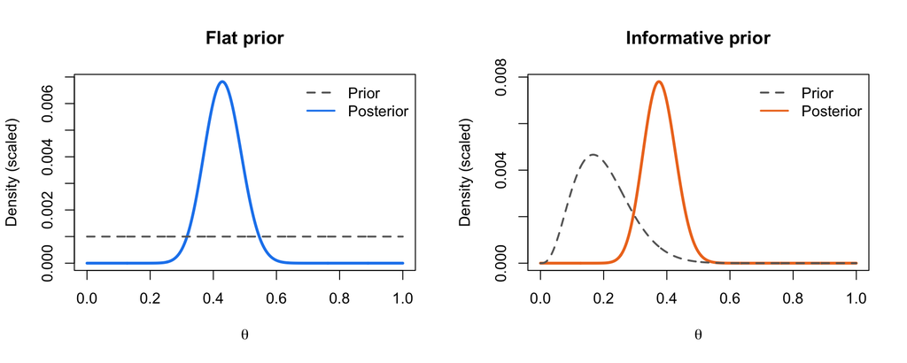

```r
theta<-seq(0, 1, length.out = 1000)

# Likelihood: binomial, the same used in a logistic GLM
likelihood<-dbinom(n_visited, size = n_plants, prob = theta)

# Two different priors
prior_flat<-dbeta(theta, 1, 1)     # uniform, everything is equally likely
prior_info<-dbeta(theta, 4, 16)    # centered around 0.2

# Posterior = likelihood x prior (then normalized to sum 1)
post_flat<-likelihood * prior_flat / sum(likelihood * prior_flat)
post_info<-likelihood * prior_info / sum(likelihood * prior_info)

par(mfrow=c(1,2))
plot(theta, post_flat, type = "l", lwd = 3, col = "dodgerblue2",
     main = "Flat prior", xlab = expression(theta), ylab = "Density (scaled)")
lines(theta, prior_flat / sum(prior_flat), lwd = 2, lty = 2, col = "grey40")
legend("topright", c("Prior", "Posterior"), lty = c(2,1), lwd = 2,
       col = c("grey40", "dodgerblue2"), bty = "n")

plot(theta, post_info, type = "l", lwd = 3, col = "chocolate2",
     main = "Informative prior", xlab = expression(theta), ylab = "Density (scaled)")
lines(theta, prior_info / sum(prior_info), lwd = 2, lty = 2, col = "grey40")
legend("topright", c("Prior", "Posterior"), lty = c(2,1), lwd = 2,
       col = c("grey40", "chocolate2"), bty = "n")
```

```r
par(mfrow=c(1,1))
```

With a flat prior, the posterior peaks at the observed proportion (0.43), just as a frequentist estimate would. With the informative prior, the posterior is pulled a bit towards 0.2, but 70 plants are enough data to largely override it. That is the key idea: **priors matter less as data accumulate**.

Now, the beauty of having a posterior distribution is that we can ask any question directly from it:

```r
# Sample 10,000 values from the (flat prior) posterior
set.seed(22)
samples<-sample(theta, size = 10000, replace = TRUE, prob = post_flat)

# Posterior median and 95% credible interval
median(samples)
```

```
## [1] 0.4304304
```

```r
quantile(samples, c(0.025, 0.975))
```

```
##      2.5%     97.5%
## 0.3173173 0.5435435
```

```r
# Probability that more than half of the plants get visited
mean(samples > 0.5)
```

```
## [1] 0.1179
```

Please notice the interpretation: the 95% **credible interval** means that, given our data and prior, there is a 95% probability that $\theta$ lies within that range. That is what most people *think* a frequentist confidence interval means (but it does not!).

Grid approximation works great with one parameter, but it becomes impossible with the 5, 10, or 50 parameters of a real model. For that we need **Markov Chain Monte Carlo (MCMC)** sampling, and this is where `brms` comes in.

# Introducing the `brms` package

`brms` (by Paul-Christian Bürkner) is an R package that lets us write Bayesian models using the same formula syntax we already know from `lm()`, `glm()`, and `lme4`. Behind the scenes, `brms` translates our formula into [Stan](https://mc-stan.org) code, compiles it into a C++ program, and samples the posterior using Hamiltonian Monte Carlo (a very efficient MCMC algorithm). We do not need to write any Stan code at all (although we can look at it using `stancode()`).

Some important things before we start:

- The first time a model is fitted, it needs to be **compiled**, which takes 30-60 seconds. Be patient, it is normal!
- Stan needs a C++ compiler. On Windows install [Rtools](https://cran.r-project.org/bin/windows/Rtools/), on macOS install Xcode command line tools (`xcode-select --install`).
- Here we use the default `rstan` backend. If you install the `cmdstanr` package (not on CRAN, see [here](https://mc-stan.org/cmdstanr/)) you can add `backend = "cmdstanr"` to any `brm()` call to make things faster.

```r
library(brms)        # Bayesian regression models using Stan
library(bayesplot)   # Plots for MCMC diagnostics and posteriors
library(posterior)   # Handling posterior draws
library(loo)         # Model comparison with leave-one-out cross-validation
library(MASS)        # glm.nb for comparison
library(ggplot2)

# Use all the cores available to run chains in parallel
options(mc.cores = parallel::detectCores())

##Some ggplot2 grooming
My_Theme = theme(
  axis.title.x = element_text(size = 16,face="bold"),
  axis.text.x = element_text(size = 12),
  axis.text.y = element_text(size = 12),
  axis.title.y = element_text(size = 16,face="bold"),
  legend.text = element_text(size = 12),
  legend.title = element_text(size = 12,face="bold"),
  panel.grid.major = element_blank(),
  panel.grid.minor = element_blank(),
  panel.background = element_rect(fill = "white"))
```

## The Bayesian workflow

Fitting a Bayesian model is not just pressing a button. A good workflow has these steps:

1. **Choose the likelihood** (data distribution), just as we learned in lesson 11.
2. **Choose the priors**, and check what they imply using a **prior predictive check**.
3. **Fit the model** (MCMC sampling).
4. **Check convergence**: R-hat, effective sample size (ESS), and divergent transitions.
5. **Check the model fit** using **posterior predictive checks**.
6. **Interpret** the posterior: effect sizes, credible intervals, and probabilities of direction.
7. **Compare models**, if needed, using cross-validation (LOO).

Let’s go through each step with real data.

# Example 1: Counting marsupial visits (again!)

In lesson 11 we modeled the number of *Dromiciops gliroides* visits to mistletoe plants as a function of temperature, humidity, luminosity (all standardized), and habitat (native forest vs. novel *Eucalyptus* plantation). We found overdispersion and switched from a Poisson to a negative binomial GLM. Let’s recall that result:

```r
model_freq<-glm.nb(dg_visits ~ temp_std + hum_std + lum_std + s250clasif, data=data)
summary(model_freq)
```

```
##
## Call:
## glm.nb(formula = dg_visits ~ temp_std + hum_std + lum_std + s250clasif,
##     data = data, init.theta = 0.4605669803, link = log)
##
## Coefficients:
##                 Estimate Std. Error z value Pr(>|z|)
## (Intercept)      0.03939    0.33094   0.119    0.905
## temp_std         0.15343    0.35896   0.427    0.669
## hum_std         -0.12691    0.37526  -0.338    0.735
## lum_std         -0.29662    0.26906  -1.102    0.270
## s250clasifNovel  0.14229    0.53111   0.268    0.789
##
## (Dispersion parameter for Negative Binomial(0.4606) family taken to be 1)
##
##     Null deviance: 63.740  on 69  degrees of freedom
## Residual deviance: 60.978  on 65  degrees of freedom
## AIC: 213.35
##
## Number of Fisher Scoring iterations: 1
##
##
##               Theta:  0.461
##           Std. Err.:  0.147
##
##  2 x log-likelihood:  -201.347
```

Now let’s do the same using the Bayesian way.

## Step 1 and 2: likelihood and priors

We will use a negative binomial likelihood. For the priors, let’s see what `brms` would use by default:

```r
get_prior(dg_visits ~ temp_std + hum_std + lum_std + s250clasif,
          family = negbinomial(), data = data)
```

```
##                    prior     class            coef group resp dpar nlpar lb ub
##                   (flat)         b
##                   (flat)         b         hum_std
##                   (flat)         b         lum_std
##                   (flat)         b s250clasifNovel
##                   (flat)         b        temp_std
##  student_t(3, -2.3, 2.5) Intercept
##      inv_gamma(0.4, 0.3)     shape                                        0
##  tag       source
##           default
##      (vectorized)
##      (vectorized)
##      (vectorized)
##      (vectorized)
##           default
##           default
```

By default, the slopes (`class = b`) have flat priors (i.e., any value from $-\infty$ to $+\infty$ is equally likely). That is not very sensible: a slope of 50 on the log scale would mean that a one-SD increase in temperature multiplies visits by $e^{50}$! We know that is nonsense. So, we will use **weakly informative priors**: they do not push the results in any direction, but they rule out absurd values.

```r
priors_nb<-c(prior(normal(0, 1), class = "b"),           # slopes (log scale)
             prior(normal(0, 1.5), class = "Intercept"), # baseline visits
             prior(exponential(1), class = "shape"))     # overdispersion
```

A `normal(0, 1)` prior on a log-scale slope means that we expect effects to be mostly between $e^{-2} \approx 0.14$ and $e^{2} \approx 7.4$ times change in visits per SD of the predictor. Is that reasonable? We can check it by simulating data from the priors alone (a **prior predictive check**), using `sample_prior = "only"`:

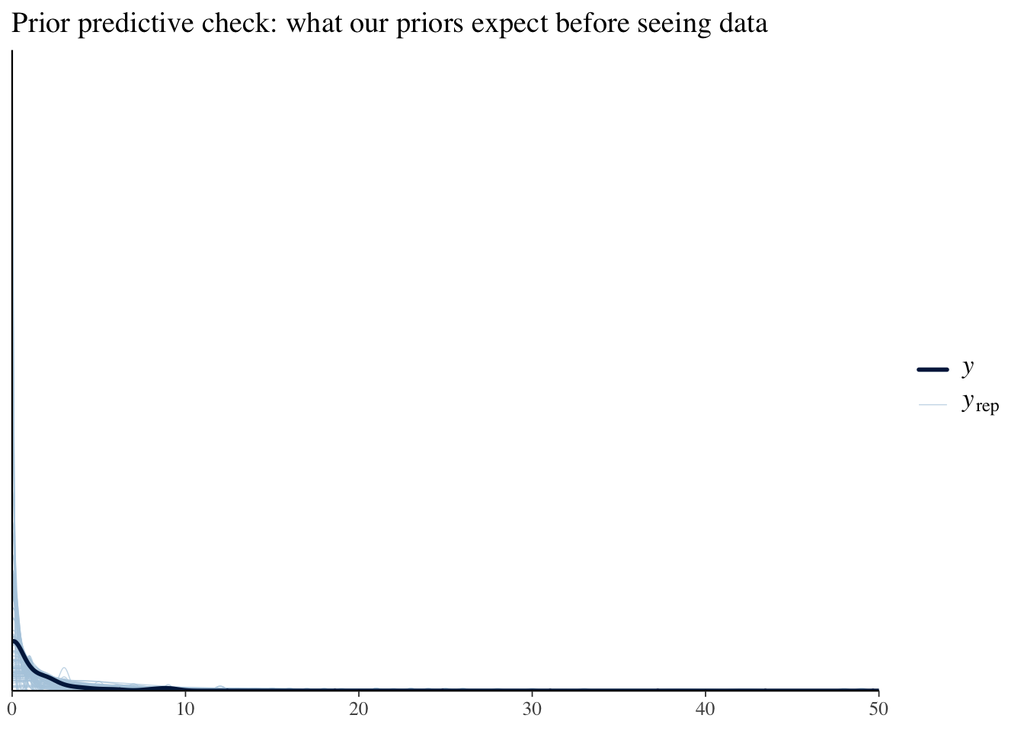

```r
prior_nb<-brm(dg_visits ~ temp_std + hum_std + lum_std + s250clasif,
              family = negbinomial(),
              prior = priors_nb,
              data = data,
              sample_prior = "only",
              seed = 22, refresh = 0)

pp_check(prior_nb, ndraws = 100) +
  scale_x_continuous(limits = c(0, 50)) +
  labs(title = "Prior predictive check: what our priors expect before seeing data")
```

The dark line is our observed data, and the light lines are datasets simulated using only the priors. They cover a wide but plausible range of counts (from zero to a few dozens of visits), so our priors are sensible.

## Step 3: fitting the model

Now we fit the model with the data. We will run 4 **chains** (independent MCMC runs) with 2000 iterations each, of which the first 1000 are **warmup** (i.e., the sampler learning where the posterior is, which is discarded).

```r
fit_nb<-brm(dg_visits ~ temp_std + hum_std + lum_std + s250clasif,
            family = negbinomial(),
            prior = priors_nb,
            data = data,
            chains = 4, iter = 2000, warmup = 1000,
            seed = 22, refresh = 0)
```

## Step 4: checking convergence

```r
summary(fit_nb)
```

```
##  Family: negbinomial
##   Links: mu = log
## Formula: dg_visits ~ temp_std + hum_std + lum_std + s250clasif
##    Data: data (Number of observations: 70)
##   Draws: 4 chains, each with iter = 2000; warmup = 1000; thin = 1;
##          total post-warmup draws = 4000
##
## Regression Coefficients:
##                 Estimate Est.Error l-95% CI u-95% CI Rhat Bulk_ESS Tail_ESS
## Intercept           0.10      0.34    -0.56     0.79 1.00     3744     2662
## temp_std            0.15      0.37    -0.58     0.86 1.00     2979     2637
## hum_std            -0.12      0.39    -0.89     0.62 1.00     2749     2643
## lum_std            -0.29      0.24    -0.78     0.19 1.00     4042     2902
## s250clasifNovel     0.10      0.56    -0.96     1.20 1.00     3689     2796
##
## Further Distributional Parameters:
##       Estimate Est.Error l-95% CI u-95% CI Rhat Bulk_ESS Tail_ESS
## shape     0.45      0.15     0.23     0.82 1.00     3539     3013
##
## Draws were sampled using sampling(NUTS). For each parameter, Bulk_ESS
## and Tail_ESS are effective sample size measures, and Rhat is the potential
## scale reduction factor on split chains (at convergence, Rhat = 1).
```

The output looks like a GLM, but with some new columns:

- **Estimate** and **Est.Error**: posterior mean and standard deviation.
- **l-95% CI** and **u-95% CI**: the 95% credible interval.
- **Rhat**: compares the chains among them. It should be < 1.01. Larger values mean the chains did not agree (i.e., they did not converge), and results cannot be trusted.
- **Bulk_ESS** and **Tail_ESS**: effective sample size. They should be > 400 (at least 100 per chain).

Also, if the sampler found problems, `brms` will warn us about **divergent transitions**. Never ignore those warnings! (Please notice that in this document warnings are hidden by the `setup` chunk, so run the code in your console to see them.) Let’s look at the chains as well (trace plots). They should look like “hairy caterpillars”, well mixed and without trends:

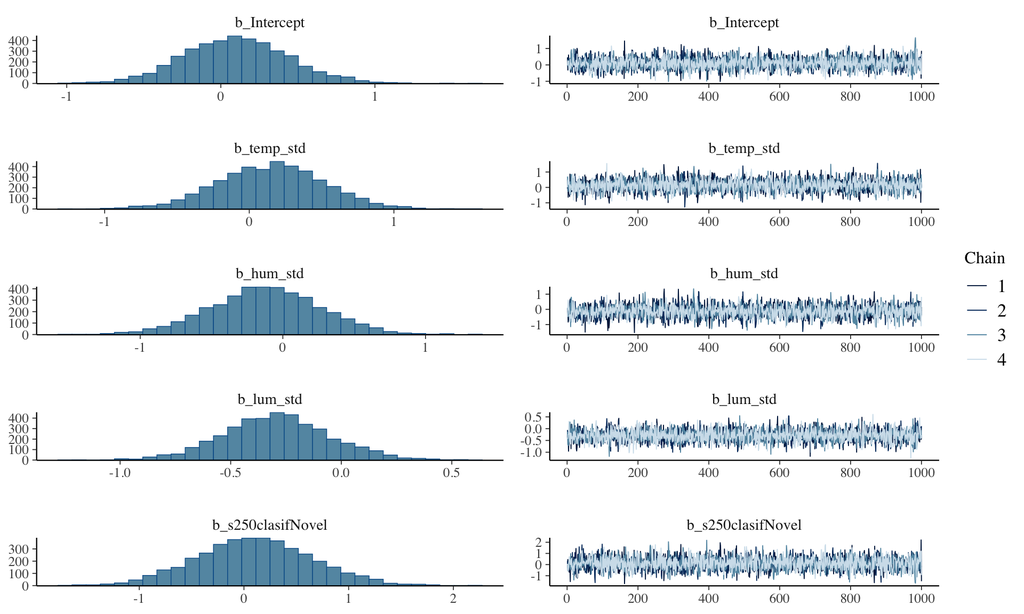

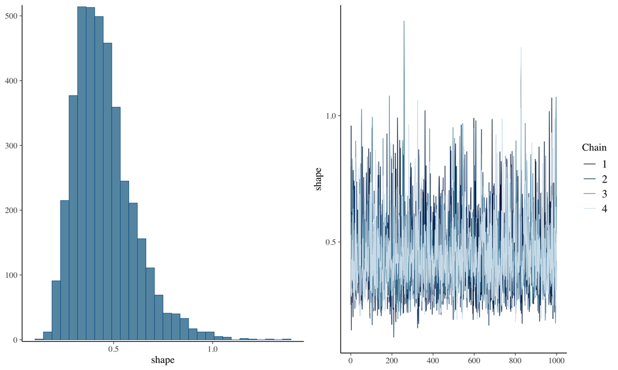

```r
plot(fit_nb, ask = FALSE)
```

Perfect! All chains overlap nicely.

## Step 5: posterior predictive checks

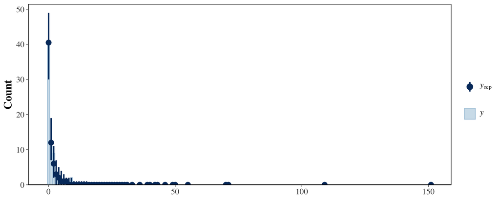

```r
pp_check(fit_nb, type = "bars", ndraws = 200) + My_Theme
```

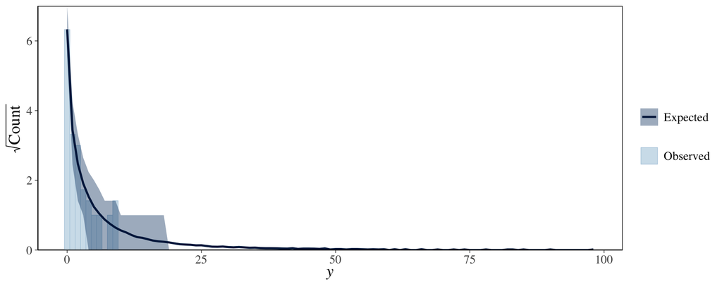

```r
pp_check(fit_nb, type = "rootogram") + My_Theme
```

## Step 6: interpreting the results

Let’s compare the Bayesian estimates with the frequentist ones:

```r
round(cbind(Frequentist = coef(model_freq),
            Bayesian = fixef(fit_nb)[, "Estimate"]), 3)
```

```
##                 Frequentist Bayesian
## (Intercept)           0.039    0.100
## temp_std              0.153    0.150
## hum_std              -0.127   -0.121
## lum_std              -0.297   -0.292
## s250clasifNovel       0.142    0.103
```

Pretty similar, as expected when the priors are weakly informative. In both cases, all the credible intervals (and the confidence intervals) include zero, so none of the predictors has a clear effect on *Dromiciops* visits. But now we have much more information. Let’s visualize the full posteriors of the slopes:

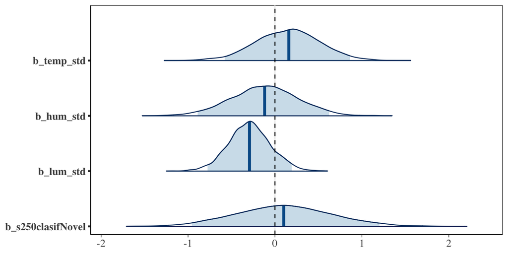

```r
mcmc_areas(fit_nb, pars = c("b_temp_std", "b_hum_std", "b_lum_std", "b_s250clasifNovel"),
           prob = 0.95) +
  geom_vline(xintercept = 0, linetype = 2) + My_Theme
```

The shaded areas are the 95% credible intervals. And now we can ask direct questions, like “what is the probability that visits are lower in the novel habitat?”, using the `hypothesis()` function:

```r
hypothesis(fit_nb, "s250clasifNovel < 0")
```

```
## Hypothesis Tests for class b:
##              Hypothesis Estimate Est.Error CI.Lower CI.Upper Evid.Ratio
## 1 (s250clasifNovel) < 0      0.1      0.56     -0.8     1.03       0.74
##   Post.Prob Star
## 1      0.43
## ---
## 'CI': 90%-CI for one-sided and 95%-CI for two-sided hypotheses.
## '*': For one-sided hypotheses, the posterior probability exceeds 95%;
## for two-sided hypotheses, the value tested against lies outside the 95%-CI.
## Posterior probabilities of point hypotheses assume equal prior probabilities.
```

```r
hypothesis(fit_nb, "temp_std > 0")
```

```
## Hypothesis Tests for class b:
##       Hypothesis Estimate Est.Error CI.Lower CI.Upper Evid.Ratio Post.Prob Star
## 1 (temp_std) > 0     0.15      0.37    -0.45     0.75       1.93      0.66
## ---
## 'CI': 90%-CI for one-sided and 95%-CI for two-sided hypotheses.
## '*': For one-sided hypotheses, the posterior probability exceeds 95%;
## for two-sided hypotheses, the value tested against lies outside the 95%-CI.
## Posterior probabilities of point hypotheses assume equal prior probabilities.
```

The column **Post.Prob** is the posterior probability of our hypothesis, and **Evid.Ratio** tells us how many times more likely the hypothesis is than its opposite. This is much more intuitive than a *p*-value!

In our case, the probability that visits are lower in the novel habitat is 0.43 and the probability of a positive temperature effect is 0.66. Both are close to a coin flip (0.5), so our data simply cannot tell us the direction of these effects. A non-significant *p*-value does not distinguish between “there is no effect” and “we don’t know”; posterior probabilities near 0.5 and wide credible intervals clearly tell us that **we don’t know** (more data are needed).

We can also work directly with the **posterior draws**, and compute any quantity we want (with its uncertainty!). For example, the change in visits on the natural scale:

```r
draws<-as_draws_df(fit_nb)
head(draws[, 1:6])
```

```
## # A tibble: 6 × 6
##   b_Intercept b_temp_std b_hum_std b_lum_std b_s250clasifNovel shape
##         <dbl>      <dbl>     <dbl>     <dbl>             <dbl> <dbl>
## 1      0.460     -0.0789    -0.200    -0.285            -0.255 0.251
## 2     -0.315      0.307     -0.114    -0.381             0.456 0.959
## 3     -0.0209    -0.636     -0.835    -0.378             0.304 0.152
## 4      0.603     -0.260     -0.707    -0.955            -0.282 0.429
## 5      0.0576    -0.120     -0.577    -0.536            -0.558 0.318
## 6      0.301     -0.330     -0.465    -0.129            -0.683 0.439
```

```r
# Multiplicative change in visits in Novel vs Native habitat (rate ratio)
rr_novel<-exp(draws$b_s250clasifNovel)
median(rr_novel)
```

```
## [1] 1.106813
```

```r
quantile(rr_novel, c(0.025, 0.975))
```

```
##     2.5%    97.5%
## 0.384515 3.327687
```

Visits in the novel habitat are about 1.1 times those in the native forest, but the 95% credible interval goes from about 0.4 (less than half the visits) to more than 3 times the visits. Again: a lot of uncertainty.

Finally, a plot of the predicted visits (conditional effects):

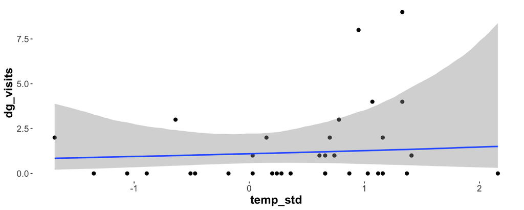

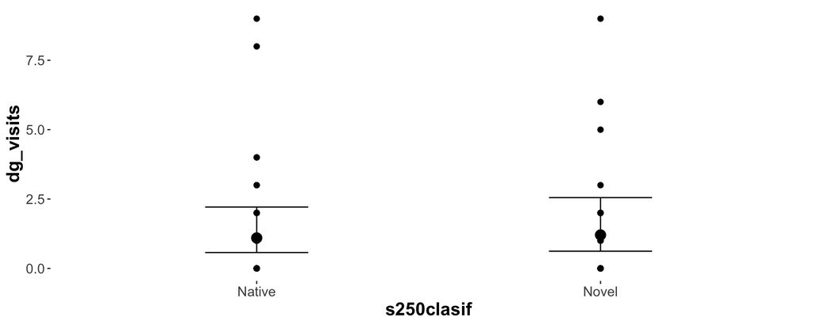

```r
ce<-conditional_effects(fit_nb, effects = c("temp_std", "s250clasif"))
plot(ce, ask = FALSE, points = TRUE, theme = My_Theme)
```

## Step 7: comparing models

We have a lot of zeros in our response variable (40 out of 70 plants had no visits). In lesson 12 we learned zero-inflated models. In `brms` we can go one step further and model the zero-inflation probability with its own predictors (this is called **distributional regression**). Let’s fit a Poisson and a zero-inflated negative binomial model, in which the probability of a structural zero depends on habitat:

```r
fit_pois<-brm(dg_visits ~ temp_std + hum_std + lum_std + s250clasif,
              family = poisson(),
              prior = c(prior(normal(0, 1), class = "b"),
                        prior(normal(0, 1.5), class = "Intercept")),
              data = data, seed = 22, refresh = 0)

fit_zinb<-brm(bf(dg_visits ~ temp_std + hum_std + lum_std + s250clasif,
                 zi ~ s250clasif),
              family = zero_inflated_negbinomial(),
              prior = c(priors_nb,
                        prior(normal(0, 1.5), class = "b", dpar = "zi")),
              data = data, seed = 22, refresh = 0)
summary(fit_zinb)
```

```
##  Family: zero_inflated_negbinomial
##   Links: mu = log; zi = logit
## Formula: dg_visits ~ temp_std + hum_std + lum_std + s250clasif
##          zi ~ s250clasif
##    Data: data (Number of observations: 70)
##   Draws: 4 chains, each with iter = 2000; warmup = 1000; thin = 1;
##          total post-warmup draws = 4000
##
## Regression Coefficients:
##                    Estimate Est.Error l-95% CI u-95% CI Rhat Bulk_ESS Tail_ESS
## Intercept              0.29      0.36    -0.40     1.02 1.00     3518     2893
## zi_Intercept          -1.82      1.22    -4.81    -0.05 1.00     2552     2469
## temp_std               0.15      0.38    -0.60     0.90 1.00     3350     2695
## hum_std               -0.11      0.40    -0.89     0.67 1.00     2974     2901
## lum_std               -0.27      0.26    -0.78     0.26 1.00     4296     2519
## s250clasifNovel        0.17      0.58    -0.93     1.33 1.00     3386     3136
## zi_s250clasifNovel     0.20      1.13    -2.14     2.39 1.00     3761     2578
##
## Further Distributional Parameters:
##       Estimate Est.Error l-95% CI u-95% CI Rhat Bulk_ESS Tail_ESS
## shape     0.74      0.40     0.29     1.77 1.00     2806     2473
##
## Draws were sampled using sampling(NUTS). For each parameter, Bulk_ESS
## and Tail_ESS are effective sample size measures, and Rhat is the potential
## scale reduction factor on split chains (at convergence, Rhat = 1).
```

Instead of AIC, Bayesian models are compared using **leave-one-out cross-validation (LOO)**, which estimates how well each model would predict new data. The `loo_compare()` function ranks the models: the first row is the best one, and differences (`elpd_diff`) smaller than about twice their standard error (`se_diff`) are not meaningful.

```r
loo_pois<-loo(fit_pois)
loo_nb<-loo(fit_nb)
loo_zinb<-loo(fit_zinb)

loo_compare(loo_pois, loo_nb, loo_zinb)
```

```
##     model elpd_diff se_diff p_worse diag_diff      diag_elpd
##    fit_nb       0.0     0.0      NA           1 k_psis > 0.7
##  fit_zinb      -1.2     0.7    0.95   N < 100 1 k_psis > 0.7
##  fit_pois     -34.8    12.7    1.00   N < 100 1 k_psis > 0.7
```

The negative binomial model is the best one. The zero-inflated negative binomial is only 1.2 units worse (with a standard error of 0.7), so both models predict equally well, and we should keep the simpler one (negative binomial). Once overdispersion is accounted for, we do not need an extra zero-inflation process: the `zi_Intercept` of the ZINB model is small (-1.82 on the logit scale, i.e., about 14% of structural zeros) and very uncertain, and it does not differ between habitats. The Poisson model is far behind (almost 35 units worse), confirming what we found in lesson 11.

Also, check the **Pareto k** diagnostics in each `loo` object: values > 0.7 mean that some observations are very influential and the LOO estimate may be unreliable.

```r
loo_nb
```

```
##
## Computed from 4000 by 70 log-likelihood matrix.
##
##          Estimate   SE
## elpd_loo   -106.7 11.3
## p_loo         5.4  1.6
## looic       213.3 22.6
## ------
## MCSE of elpd_loo is NA.
## MCSE and ESS estimates assume MCMC draws (r_eff in [0.7, 1.2]).
##
## Pareto k diagnostic values:
##                          Count Pct.    Min. ESS
## (-Inf, 0.7]   (good)     69    98.6%   886
##    (0.7, 1]   (bad)       1     1.4%   <NA>
##    (1, Inf)   (very bad)  0     0.0%   <NA>
## See help('pareto-k-diagnostic') for details.
```

We have one plant with a bad Pareto k (the `diag_elpd` column of `loo_compare()` warned us about this too). One single observation will not change the ranking here, but in a paper we should re-check it with `loo(fit_nb, moment_match = TRUE)` or `kfold(fit_nb, K = 10)`.

# Example 2: Seed removal as a binomial process

In the same study, we measured the proportion of fruits removed from each plant (*removal*), and we also know the crop size (number of fruits) of each plant. A proportion based on counts should not be analyzed as a Gaussian variable (nor transformed): the proper approach is a **binomial** model with the number of trials. In `brms` we use the `| trials()` syntax:

```r
data$removed<-round(data$removal * data$crop_size)
data$dg_std<-as.numeric(scale(data$dg_visits))
head(data[, c("plant_tag", "crop_size", "removal", "removed", "dg_visits", "s250clasif")])
```

```
##   plant_tag crop_size removal removed dg_visits s250clasif
## 1      QM02       150     0.2      30         2      Novel
## 2      QM03         6     1.0       6         2      Novel
## 3      QM04        10     1.0      10         3      Novel
## 4      QM05        30     0.3       9         1      Novel
## 5      QM06         6     1.0       6         0      Novel
## 6      QM07        10     1.0      10         0      Novel
```

```r
fit_bin<-brm(removed | trials(crop_size) ~ dg_std + s250clasif,
             family = binomial(),
             prior = c(prior(normal(0, 1), class = "b"),
                       prior(normal(0, 1.5), class = "Intercept")),
             data = data, seed = 22, refresh = 0)
summary(fit_bin)
```

```
##  Family: binomial
##   Links: mu = logit
## Formula: removed | trials(crop_size) ~ dg_std + s250clasif
##    Data: data (Number of observations: 70)
##   Draws: 4 chains, each with iter = 2000; warmup = 1000; thin = 1;
##          total post-warmup draws = 4000
##
## Regression Coefficients:
##                 Estimate Est.Error l-95% CI u-95% CI Rhat Bulk_ESS Tail_ESS
## Intercept          -1.13      0.05    -1.23    -1.03 1.00     4313     3320
## dg_std              0.33      0.04     0.25     0.42 1.00     4445     3061
## s250clasifNovel     0.37      0.08     0.22     0.52 1.00     4114     2724
##
## Draws were sampled using sampling(NUTS). For each parameter, Bulk_ESS
## and Tail_ESS are effective sample size measures, and Rhat is the potential
## scale reduction factor on split chains (at convergence, Rhat = 1).
```

Let’s check if this model reproduces the observed proportions:

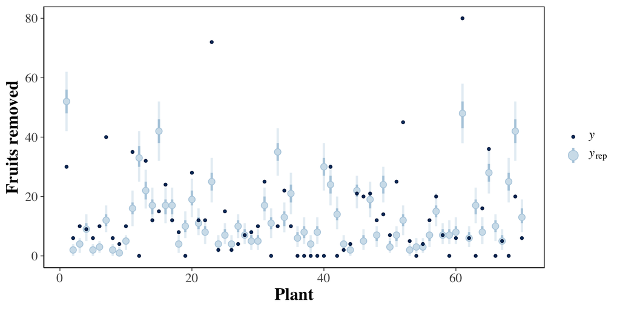

```r
pp_check(fit_bin, type = "intervals") + My_Theme +
  labs(x = "Plant", y = "Fruits removed")
```

Doh! Many observed values (dark dots) fall outside the predicted intervals, which are extremely narrow. This is **overdispersion** in a binomial model: plants differ among them much more than a binomial distribution allows (e.g., some plants lost all their fruits and others none, regardless of the number of visits). Please notice how small the standard errors of the coefficients are in the summary above: ignoring overdispersion makes us overconfident.

The count analogue of this problem was solved using the negative binomial distribution instead of the Poisson one. For proportions, the analogue is the **beta-binomial distribution**: each plant has its own removal probability, which varies around the mean following a Beta distribution with a precision parameter `phi` (the smaller `phi`, the larger the overdispersion).

```r
fit_bb<-brm(removed | trials(crop_size) ~ dg_std + s250clasif,
            family = beta_binomial(),
            prior = c(prior(normal(0, 1), class = "b"),
                      prior(normal(0, 1.5), class = "Intercept"),
                      prior(exponential(0.1), class = "phi")),
            data = data, seed = 22, refresh = 0)
summary(fit_bb)
```

```
##  Family: beta_binomial
##   Links: mu = logit
## Formula: removed | trials(crop_size) ~ dg_std + s250clasif
##    Data: data (Number of observations: 70)
##   Draws: 4 chains, each with iter = 2000; warmup = 1000; thin = 1;
##          total post-warmup draws = 4000
##
## Regression Coefficients:
##                 Estimate Est.Error l-95% CI u-95% CI Rhat Bulk_ESS Tail_ESS
## Intercept          -0.95      0.23    -1.39    -0.50 1.00     4082     3152
## dg_std              0.44      0.19     0.08     0.83 1.00     4420     2651
## s250clasifNovel     0.98      0.32     0.35     1.61 1.00     3974     2948
##
## Further Distributional Parameters:
##     Estimate Est.Error l-95% CI u-95% CI Rhat Bulk_ESS Tail_ESS
## phi     1.22      0.23     0.82     1.75 1.00     3889     3262
##
## Draws were sampled using sampling(NUTS). For each parameter, Bulk_ESS
## and Tail_ESS are effective sample size measures, and Rhat is the potential
## scale reduction factor on split chains (at convergence, Rhat = 1).
```

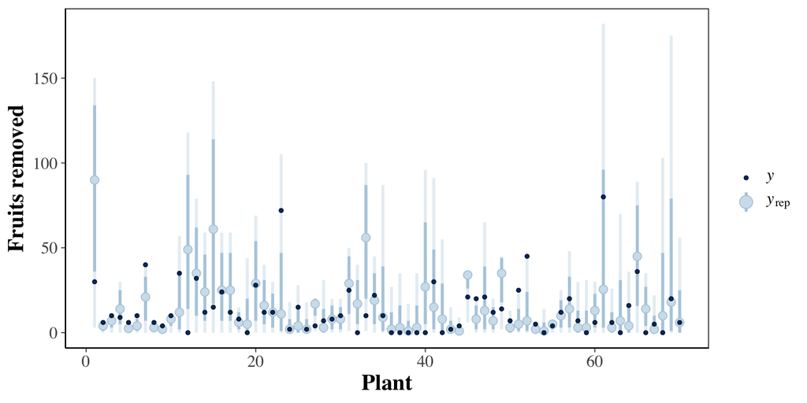

```r
pp_check(fit_bb, type = "intervals") + My_Theme +
  labs(x = "Plant", y = "Fruits removed")
```

Much better! Now the predictive intervals are wide enough to include almost all the observed values. The precision parameter is low (`phi` around 1.2), confirming strong overdispersion, and the credible intervals of the slopes are 4-5 times wider than in the binomial model. Even so, both effects remain clearly positive: plants with more *Dromiciops* visits lost a larger proportion of their fruits (which makes sense, as this marsupial is the main seed disperser of this mistletoe), and removal was higher in the novel habitat.

Another common solution is adding an **observation-level random effect** (i.e., `+ (1 | plant_tag)`, one random intercept per plant). It works, but be careful: with one random effect per observation, the model reproduces each data point almost perfectly, so a posterior predictive check like the one above is not informative anymore. It is also harder to sample (it needs more iterations to reach R-hat < 1.01 with these data).

## Predictions on the probability scale

Logit-scale coefficients are hard to interpret. With the posterior draws we can get the predicted removal probability for each habitat (for a plant with an average number of visits), and the difference between them, all with their full uncertainty:

```r
newdat<-data.frame(dg_std = 0, s250clasif = c("Native", "Novel"), crop_size = 1)
pred<-posterior_epred(fit_bb, newdata = newdat)
colnames(pred)<-c("Native", "Novel")

# Predicted removal probability
apply(pred, 2, quantile, probs = c(0.5, 0.025, 0.975))
```

```
##          Native     Novel
## 50%   0.2798686 0.5094627
## 2.5%  0.1990905 0.3908436
## 97.5% 0.3774269 0.6280971
```

```r
# Difference (Novel - Native) and probability that it is positive
diff_hab<-pred[, "Novel"] - pred[, "Native"]
quantile(diff_hab, c(0.5, 0.025, 0.975))
```

```
##        50%       2.5%      97.5%
## 0.23023875 0.07973692 0.36700621
```

```r
mean(diff_hab > 0)
```

```
## [1] 0.999
```

Plants in the novel habitat lost about half of their fruits, whereas plants in the native forest lost less than one third. The difference is about 23 percentage points (95% CI: 8-37 points), and the probability that removal is higher in the novel habitat is > 0.99.

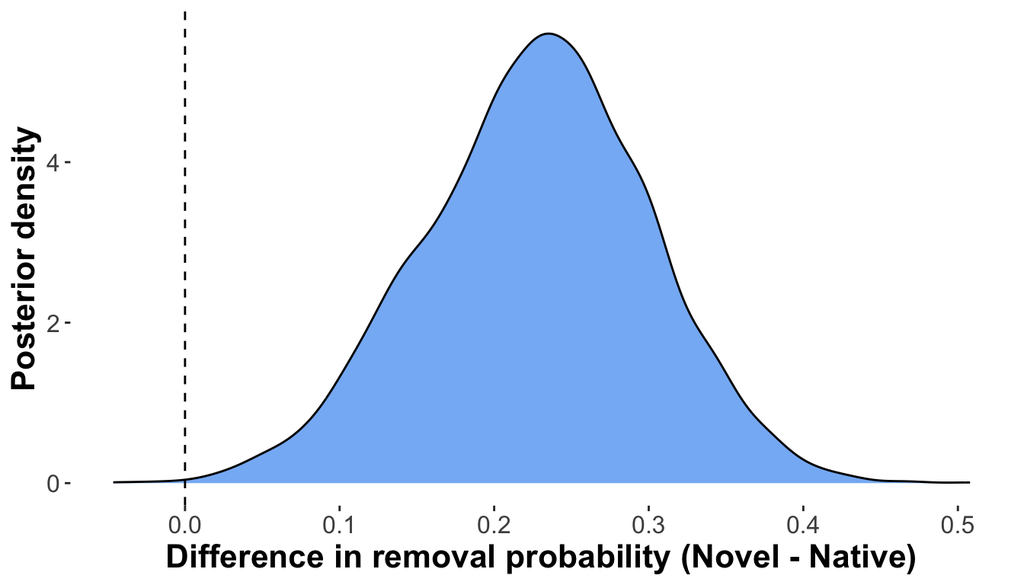

```r
ggplot(data.frame(diff = diff_hab), aes(x = diff)) +
  geom_density(fill = "dodgerblue2", alpha = 0.6) +
  geom_vline(xintercept = 0, linetype = 2) +
  labs(x = "Difference in removal probability (Novel - Native)", y = "Posterior density") +
  My_Theme
```

This is one of the most useful features of Bayesian inference: any derived quantity (differences, ratios, predictions) automatically inherits the uncertainty of all the parameters. No delta method, no bootstrap needed.

# Example 3: Hierarchical models and shrinkage

In lesson 14 we used the data of [Cordero et al. 2020](https://www.mdpi.com/2071-1050/12/21/9252) to model the proportion of threatened mammal species per country, using *Geography* as a random factor. Here we will make two improvements:

1. The response is a proportion bounded between 0 and 1 (not based on counts), so instead of transforming it, we will use a **Beta distribution**.
2. We will use *Continent* as a random effect. Some continents are represented by only 2 or 3 countries, a situation in which frequentist mixed models often produce singular fits. Bayesian hierarchical models handle this gracefully thanks to the priors.

```r
threat<-read.table("data/10_data_threat.txt",
                     header=TRUE,
                     sep="\t",
                     dec=",",
                     na.strings="NA")

# Standardizing predictors makes priors easier to set (and sampling more efficient)
threat$urb_z<-as.numeric(scale(threat$Urbanization))
threat$dens_z<-as.numeric(scale(log(threat$Pop_density)))
threat$educ_z<-as.numeric(scale(threat$education_GDP))
threat$prot_z<-as.numeric(scale(threat$perc_prot_land))

table(threat$Continent)
```

```
##
##          Africa            Asia Central_America          Europe   North America
##              43              32              14              33               2
##         Oceania   South America
##               3              11
```

```r
summary(threat$prop_thr_mammals17)
```

```
##    Min. 1st Qu.  Median    Mean 3rd Qu.    Max.
##  0.0100  0.0600  0.1000  0.1149  0.1375  0.7300
```

```r
fit_beta<-brm(prop_thr_mammals17 ~ urb_z + dens_z + educ_z + prot_z + (1 | Continent),
              family = Beta(),
              prior = c(prior(normal(0, 1), class = "b"),
                        prior(normal(-2, 1), class = "Intercept"),   # ~12% threatened
                        prior(exponential(2), class = "sd"),
                        prior(gamma(2, 0.1), class = "phi")),
              data = threat, seed = 22, refresh = 0,
              control = list(adapt_delta = 0.95))
summary(fit_beta)
```

```
##  Family: beta
##   Links: mu = logit
## Formula: prop_thr_mammals17 ~ urb_z + dens_z + educ_z + prot_z + (1 | Continent)
##    Data: threat (Number of observations: 138)
##   Draws: 4 chains, each with iter = 2000; warmup = 1000; thin = 1;
##          total post-warmup draws = 4000
##
## Multilevel Hyperparameters:
## ~Continent (Number of levels: 7)
##               Estimate Est.Error l-95% CI u-95% CI Rhat Bulk_ESS Tail_ESS
## sd(Intercept)     0.46      0.19     0.20     0.92 1.00     1353     2390
##
## Regression Coefficients:
##           Estimate Est.Error l-95% CI u-95% CI Rhat Bulk_ESS Tail_ESS
## Intercept    -2.00      0.20    -2.39    -1.60 1.00     1666     1842
## urb_z        -0.01      0.06    -0.13     0.11 1.00     4210     2462
## dens_z        0.11      0.06    -0.01     0.23 1.00     4113     2806
## educ_z       -0.07      0.05    -0.18     0.03 1.00     4790     2868
## prot_z       -0.06      0.06    -0.19     0.06 1.00     5395     2872
##
## Further Distributional Parameters:
##     Estimate Est.Error l-95% CI u-95% CI Rhat Bulk_ESS Tail_ESS
## phi    20.00      2.51    15.27    25.19 1.00     3867     2856
##
## Draws were sampled using sampling(NUTS). For each parameter, Bulk_ESS
## and Tail_ESS are effective sample size measures, and Rhat is the potential
## scale reduction factor on split chains (at convergence, Rhat = 1).
```

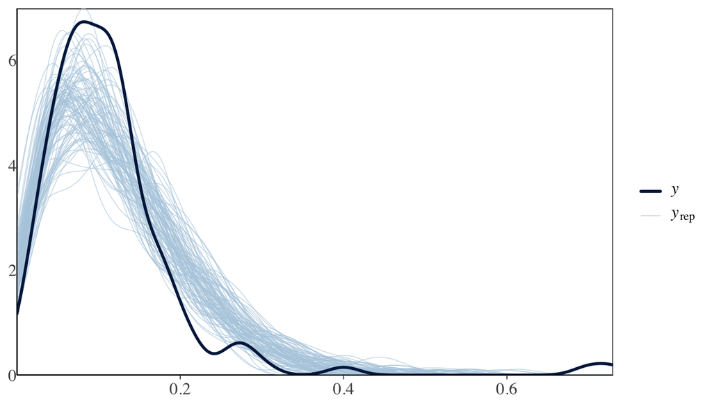

```r
pp_check(fit_beta, ndraws = 100) + My_Theme
```

Please notice that we increased `adapt_delta` to 0.95: this makes the sampler take smaller steps, which helps avoiding divergent transitions in hierarchical models.

None of the four predictors has a strong effect: all the slopes are small and their credible intervals include (or almost include) zero. Population density shows the most consistent effect (a positive slope, with most of the posterior above zero; check it with `hypothesis(fit_beta, "dens_z > 0")`).

The **Multilevel Hyperparameters** section shows the standard deviation among continents (`sd(Intercept)` = 0.46), which is larger than any of the slopes: *where* a country is matters more than its urbanization or education investment. Let’s look at the continent-level estimates (the random intercepts, as deviations from the overall intercept):

```r
ranef(fit_beta)$Continent[, , "Intercept"]
```

```
##                     Estimate Est.Error        Q2.5      Q97.5
## Africa           0.050194723 0.2188203 -0.39903310  0.4756001
## Asia             0.287340650 0.2167269 -0.14440963  0.7192228
## Central_America -0.239761044 0.2434954 -0.73803343  0.2358386
## Europe          -0.540419433 0.2313926 -1.03186318 -0.1159751
## North America   -0.100203004 0.3430739 -0.85187148  0.5228256
## Oceania          0.540997399 0.3504738 -0.08154317  1.2761115
## South America   -0.002550124 0.2458135 -0.47652806  0.4914484
```

European countries have a clearly lower proportion of threatened mammals than the average (its interval excludes zero), whereas Oceania and Asia tend to have higher proportions, although with more uncertainty.

## What is shrinkage?

Hierarchical models do **partial pooling**: the estimate of each group is a compromise between its own data and the overall mean. Groups with few observations (e.g., Oceania or North America) are pulled more strongly towards the overall mean, because we have less information about them. This is called **shrinkage**, and it protects us from over-interpreting groups with small samples. To see it clearly, let’s fit a simpler model with no predictors (only the continent random intercept), so that the only difference between the raw and the pooled estimates is the pooling itself:

```r
fit_beta0<-brm(prop_thr_mammals17 ~ 1 + (1 | Continent),
               family = Beta(),
               prior = c(prior(normal(-2, 1), class = "Intercept"),
                         prior(exponential(2), class = "sd"),
                         prior(gamma(2, 0.1), class = "phi")),
               data = threat, seed = 22, refresh = 0,
               control = list(adapt_delta = 0.95))
```

```r
# Raw (no pooling) estimate: mean proportion of each continent, on the logit scale
raw<-aggregate(prop_thr_mammals17 ~ Continent, data = threat,
               FUN = function(x) qlogis(mean(x)))
names(raw)[2]<-"raw"
raw$n<-as.numeric(table(threat$Continent)[raw$Continent])

# Partial pooling estimate (intercept + continent deviation)
pp<-coef(fit_beta0)$Continent[, "Estimate", "Intercept"]
raw$pooled<-pp[raw$Continent]
raw$shift<-round(raw$pooled - raw$raw, 2)
raw
```

```
##         Continent       raw  n    pooled shift
## 1          Africa -1.919593 43 -1.946453 -0.03
## 2            Asia -1.665220 32 -1.633686  0.03
## 3 Central_America -2.197225 14 -2.169775  0.03
## 4          Europe -2.762332 33 -2.538454  0.22
## 5   North America -2.586689  2 -2.165710  0.42
## 6         Oceania -1.227230  3 -1.617447 -0.39
## 7   South America -2.217592 11 -2.064735  0.15
```

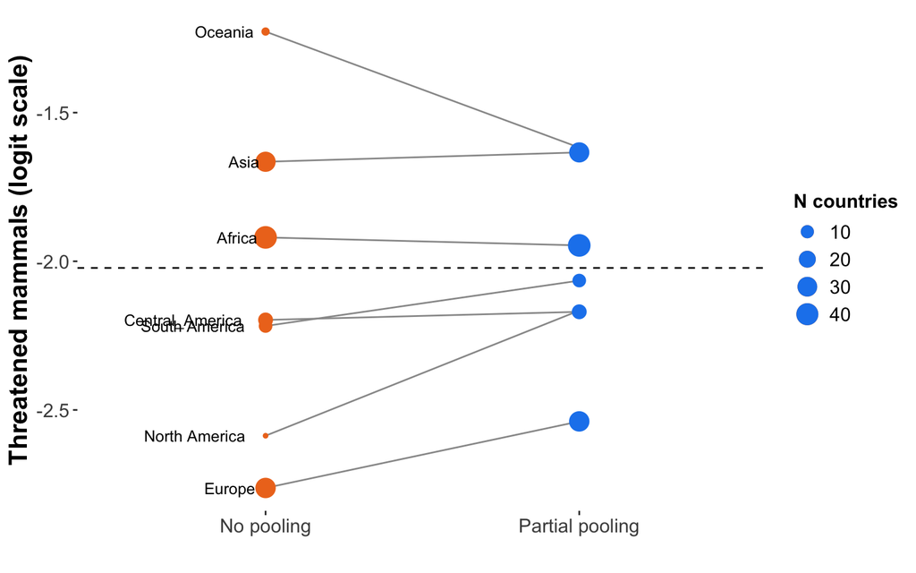

```r
ggplot(raw) +
  geom_segment(aes(x = "No pooling", xend = "Partial pooling",
                   y = raw, yend = pooled, group = Continent), colour = "grey60") +
  geom_point(aes(x = "No pooling", y = raw, size = n), colour = "chocolate2") +
  geom_point(aes(x = "Partial pooling", y = pooled, size = n), colour = "dodgerblue2") +
  geom_text(aes(x = "No pooling", y = raw, label = Continent), hjust = 1.2, size = 3.5) +
  geom_hline(yintercept = fixef(fit_beta0)["Intercept", "Estimate"], linetype = 2) +
  labs(x = "", y = "Threatened mammals (logit scale)", size = "N countries") +
  My_Theme
```

The dashed line is the overall intercept. North America (2 countries) and Oceania (3 countries) are pulled strongly towards it (a shift of about 0.4 logit units), whereas Africa, Asia, and Central America, with many countries, barely move. Europe moves a bit despite having 33 countries, because it is the most extreme group (the further from the mean, the stronger the pull). With only 2 or 3 countries, a continent-level mean can be very extreme just by chance, so shrinkage is a sensible (and automatic) correction.

# Example 4: A Bayesian meta-analysis

In lesson 21 we conducted a meta-analysis on the effect of biological control on crop damage using the data of [Diaz-Siefer et al. 2022](https://link.springer.com/article/10.1007/s10340-021-01438-4). There was a hidden problem there: several case studies come from the **same paper**, so they are not independent. A meta-analysis is just a hierarchical model with known sampling variances, so we can fit it with `brms` and add a multilevel structure (cases nested within papers) very easily. The `se()` term tells `brms` the standard error of each effect size:

```r
meta<-read.table("./data/21_data_meta_damage.txt", header = T)
meta$se<-sqrt(meta$var)
table(table(meta$paperID))   # how many cases per paper
```

```
##
##  1  2  3  4  6
## 14  6  3  4  1
```

```r
fit_meta<-brm(hedges_d | se(se) ~ 1 + (1 | paperID/caseID),
              prior = c(prior(normal(0, 1), class = "Intercept"),
                        prior(cauchy(0, 0.5), class = "sd")),
              data = meta, seed = 22, refresh = 0,
              control = list(adapt_delta = 0.99))
summary(fit_meta)
```

```
##  Family: gaussian
##   Links: mu = identity
## Formula: hedges_d | se(se) ~ 1 + (1 | paperID/caseID)
##    Data: meta (Number of observations: 57)
##   Draws: 4 chains, each with iter = 2000; warmup = 1000; thin = 1;
##          total post-warmup draws = 4000
##
## Multilevel Hyperparameters:
## ~paperID (Number of levels: 28)
##               Estimate Est.Error l-95% CI u-95% CI Rhat Bulk_ESS Tail_ESS
## sd(Intercept)     0.27      0.12     0.03     0.51 1.00      596      808
##
## ~paperID:caseID (Number of levels: 57)
##               Estimate Est.Error l-95% CI u-95% CI Rhat Bulk_ESS Tail_ESS
## sd(Intercept)     0.38      0.09     0.20     0.56 1.01      713      725
##
## Regression Coefficients:
##           Estimate Est.Error l-95% CI u-95% CI Rhat Bulk_ESS Tail_ESS
## Intercept     0.45      0.10     0.26     0.63 1.00     2568     2676
##
## Further Distributional Parameters:
##       Estimate Est.Error l-95% CI u-95% CI Rhat Bulk_ESS Tail_ESS
## sigma     0.00      0.00     0.00     0.00   NA       NA       NA
##
## Draws were sampled using sampling(NUTS). For each parameter, Bulk_ESS
## and Tail_ESS are effective sample size measures, and Rhat is the potential
## scale reduction factor on split chains (at convergence, Rhat = 1).
```

In this output, the **Intercept** is the overall effect size, `sd(Intercept)` for *paperID* is the heterogeneity among papers ($\tau$ between papers), and the one for *paperID:caseID* is the heterogeneity among cases within the same paper. Don’t worry about `sigma` being 0 with `NA` diagnostics: the residual variation is fixed by the known standard errors given in `se()`, so there is no residual SD to estimate.

The overall effect size is 0.45 (95% CI: 0.26-0.63), very close to the random-effects estimate of lesson 21 (about 0.46), and in the same direction. The credible interval is a bit wider, because now we account for the non-independence of cases from the same paper and for the uncertainty in the heterogeneity. Interestingly, heterogeneity among cases within the same paper (0.38) is larger than heterogeneity among papers (0.27). We can compute the probability that the overall effect is positive, and the probability that it is larger than a “small” effect size (0.2 in Cohen’s scale):

```r
hypothesis(fit_meta, c("Intercept > 0", "Intercept > 0.2"))
```

```
## Hypothesis Tests for class b:
##              Hypothesis Estimate Est.Error CI.Lower CI.Upper Evid.Ratio
## 1       (Intercept) > 0     0.45       0.1      0.3     0.61        Inf
## 2 (Intercept)-(0.2) > 0     0.25       0.1      0.1     0.41     116.65
##   Post.Prob Star
## 1      1.00    *
## 2      0.99    *
## ---
## 'CI': 90%-CI for one-sided and 95%-CI for two-sided hypotheses.
## '*': For one-sided hypotheses, the posterior probability exceeds 95%;
## for two-sided hypotheses, the value tested against lies outside the 95%-CI.
## Posterior probabilities of point hypotheses assume equal prior probabilities.
```

Both probabilities are > 0.99. None of the 4000 posterior draws were below zero, which is why the evidence ratio of the first hypothesis is `Inf` (it just means “larger than we can measure with 4000 draws”).

And moderators (e.g., zone) are included just like any other predictor:

```r
fit_meta_zone<-brm(hedges_d | se(se) ~ 0 + zone + (1 | paperID/caseID),
                   prior = c(prior(normal(0, 1), class = "b"),
                             prior(cauchy(0, 0.5), class = "sd")),
                   data = meta, seed = 22, refresh = 0,
                   control = list(adapt_delta = 0.99))
fixef(fit_meta_zone)
```

```
##                Estimate Est.Error      Q2.5     Q97.5
## zonetemperate 0.4531784 0.1419912 0.1759307 0.7398455
## zonetropical  0.4456621 0.1306785 0.1915866 0.7027771
```

```r
hypothesis(fit_meta_zone, "zonetropical > zonetemperate")
```

```
## Hypothesis Tests for class b:
##                 Hypothesis Estimate Est.Error CI.Lower CI.Upper Evid.Ratio
## 1 (zonetropical)-(z... > 0    -0.01      0.19    -0.31      0.3        0.9
##   Post.Prob Star
## 1      0.47
## ---
## 'CI': 90%-CI for one-sided and 95%-CI for two-sided hypotheses.
## '*': For one-sided hypotheses, the posterior probability exceeds 95%;
## for two-sided hypotheses, the value tested against lies outside the 95%-CI.
## Posterior probabilities of point hypotheses assume equal prior probabilities.
```

Using `0 + zone` we remove the intercept, so we get the mean effect size of each zone directly (instead of a difference with a reference level). Both zones have almost identical mean effect sizes (about 0.45), and the probability that the effect is larger in tropical than in temperate zones is 0.47, i.e., a coin flip: biological control seems to work equally well in both zones. This makes a forest plot super easy:

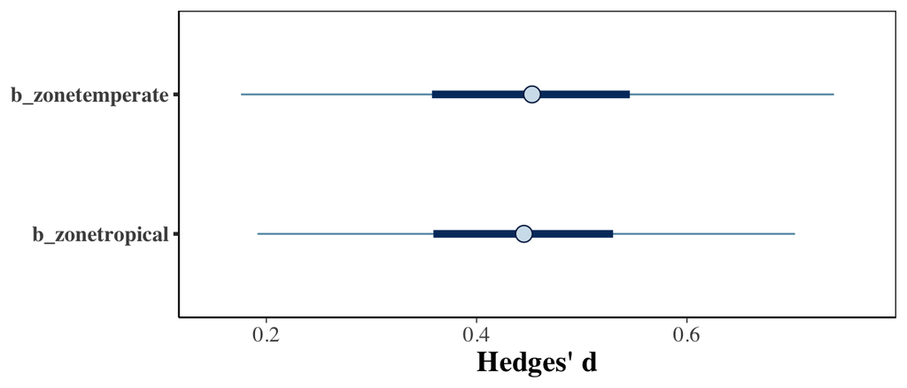

```r
mcmc_intervals(fit_meta_zone, pars = c("b_zonetemperate", "b_zonetropical"),
               prob = 0.5, prob_outer = 0.95) +
  geom_vline(xintercept = 0, linetype = 2) +
  labs(x = "Hedges' d") + My_Theme
```

# What else can `brms` do?

We only scratched the surface. The same `brm()` function can handle many other models that we have seen in this course (and more). Here there are some formulas to give you an idea (not run):

```r
# GAM with a cyclic smooth for seasonality (lesson 13 and 19)
brm(abundance ~ s(day_of_year, bs = "cc") + (1 | site), family = negbinomial(), data = d)

# Spatial model with a Gaussian process over coordinates (lesson 15)
brm(visits ~ habitat + gp(UTM_E, UTM_N), family = negbinomial(), data = d)

# Temporal autocorrelation (lesson 19)
brm(count ~ temperature + ar(time = year, gr = site, p = 1), family = poisson(), data = d)

# Ordinal responses, e.g. damage classes 0-4 (never treat them as continuous!)
brm(damage_class ~ treatment + (1 | plant), family = cumulative("logit"), data = d)

# Proportions with exact 0s and 1s (e.g., fruit set, % leaf area damaged)
brm(fruit_set ~ habitat, family = zero_one_inflated_beta(), data = d)

# Phylogenetic mixed model (A = phylogenetic covariance matrix from ape::vcv())
brm(trait ~ predictor + (1 | gr(species, cov = A)), data = d, data2 = list(A = A))

# Bayesian path analysis / SEM: several responses in one model
brm(bf(visits ~ temperature + habitat, family = negbinomial()) +
    bf(removed | trials(crop_size) ~ visits + habitat, family = binomial()) +
    set_rescor(FALSE), data = d)
```

Other useful functions: `stancode(fit)` to see the Stan code behind the model, `update(fit, newdata = ...)` to refit without recompiling, the `file = "fits/model1"` argument in `brm()` to save the fitted model and avoid refitting it every time, and the `tidybayes` and `marginaleffects` packages for tidy summaries and plots.

## How to report a Bayesian model

When writing your paper, please include:

- The likelihood (distribution and link function) and the priors (and a justification of them).
- The software (R, `brms`, Stan versions), the number of chains, iterations, and warmup.
- Convergence diagnostics (all R-hat < 1.01, ESS values, no divergent transitions).
- A posterior predictive check (usually in the Supplementary material).
- Posterior medians (or means) with 95% credible intervals, and probabilities of direction when useful. Avoid talking about “significance”!
- A prior sensitivity analysis if your results could depend on the priors (e.g., small datasets).

Reviewers are often more familiar with frequentist results, so a clear methods section goes a long way.

## Final thoughts

Bayesian statistics is not a different set of models: it is a different (and, in my opinion, more intuitive) way of learning from data. Everything we learned in this course (distributions, random effects, smooths, meta-analysis) can be fitted in a Bayesian framework with `brms`, using the same formula syntax. The main advantages are: (i) direct probability statements about our hypotheses, (ii) full uncertainty propagation to any derived quantity, (iii) stable estimates with small or unbalanced datasets (a very common situation in field ecology), and (iv) incredible flexibility to build models that fit our data, instead of forcing our data into the models available. The price to pay is computing time and the responsibility of choosing and justifying the priors. It is worth it!

## Further reading

- Bürkner, P.-C. (2017). brms: An R package for Bayesian multilevel models using Stan. *Journal of Statistical Software*, 80(1), 1-28.
- Bürkner, P.-C. (2018). Advanced Bayesian multilevel modeling with the R package brms. *The R Journal*, 10(1), 395-411.
- McElreath, R. (2020). *Statistical Rethinking*, 2nd ed. CRC Press. The best book to learn Bayesian thinking. Solomon Kurz translated the whole book to `brms` [here](https://bookdown.org/content/4857/).
- Gelman, A. et al. (2020). Bayesian workflow. [arXiv:2011.01808](https://arxiv.org/abs/2011.01808).
- The `brms` website: https://paulbuerkner.com/brms/

Licensing Creative Commons License

Licensed under a Creative Commons Attribution-ShareAlike 4.0 International License.  
2026 - Francisco E. Fontúrbel